# ggplot2 R

### 4.8.5 提琴图

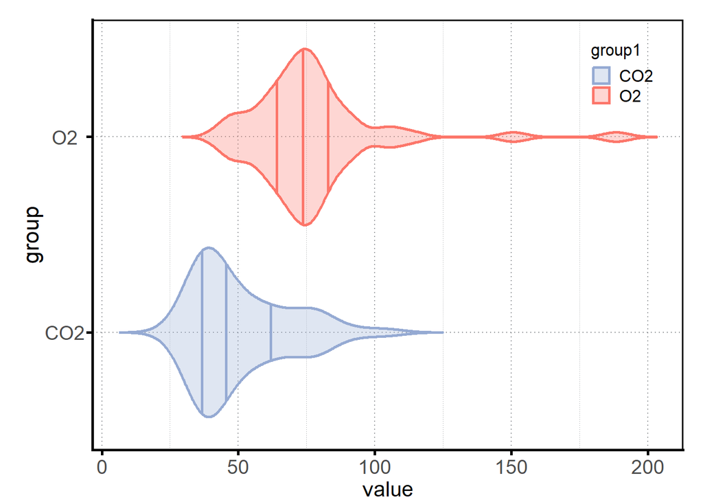

```r
> p提琴图 <- p分组框架+
+   stat_ydensity(aes(group = group, color = group, fill = group), draw_quantiles = c(0.25, 0.5, 0.75), alpha = 0.3, size = 1, trim = FALSE, geom = "violin")+
+   theme(legend.position = (c(0.95, 0.95)))+
+   scale_color_manual(values = cols)+
+   scale_fill_manual(values = fills)
> p提琴图
```

### 4.8.6 组合图

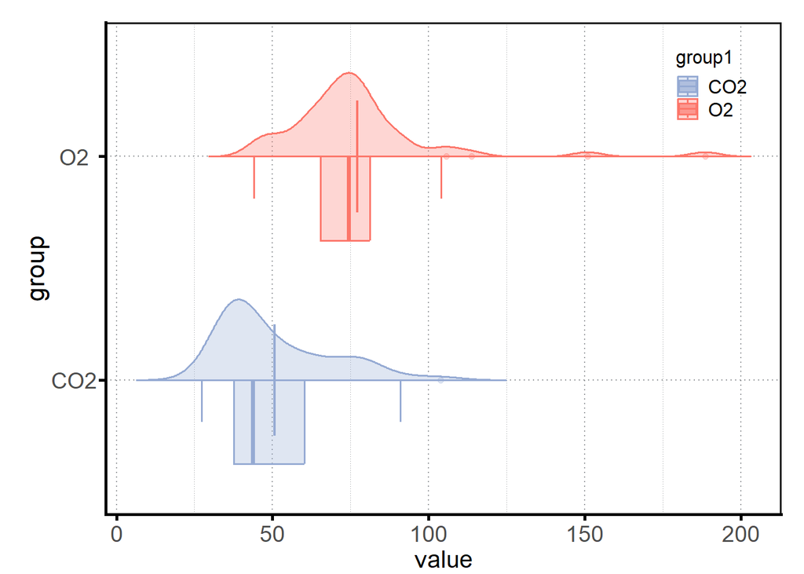

```r
> p组合图 <- p分组框架+
+   geom_half_boxplot(aes(group = group, color = group, fill = group), alpha = 0.3, size = 0.618, position = position_nudge(x = 0, y = 0), side = "l", )+
+   geom_half_violin(aes(group = group, color = group, fill = group), alpha = 0.3, size = 0.618, position = position_nudge(x = 0, y = 0), side = "r", trim = FALSE)+
+   stat_summary(aes(group = group, color = group, fill = group), fun = "mean", geom = "crossbar", alpha = 0.5, width = 0.5, size = 0.309)+
+   theme(legend.position = (c(0.95, 0.95)))+
+   scale_color_manual(values = cols)+
+   scale_fill_manual(values = fills)
> p组合图
```

## 4.9 结合统计

### 4.9.1 热图(complexHeatmap包)

```r
> mat <- import("D:/desktop/book/book/case/heatmap1.xlsx", )
> #colnames(mat) = mat[1, ]
> #rownames(mat) = mat[, 1]
> mat <- as.matrix(mat)#矩阵化
> mat
```

```
   ...1      ACC           BLCA          COAD          CESC
1  "TPPP2"   "-0.13771959" "-0.10338264" "-0.48821828" " 0.30326818"
2  "BCAR3"   " 0.25526632" " 0.42559408" " 0.77428486" "-0.01857988"
3  "TLX1"    " 0.20881356" "-0.08403459" "-0.61451625" " 0.03266747"
4  "OR6B3"   " 0.24090469" "-0.40767764" "-0.17316252" "-0.62431101"
5  "TP53"    " 0.20234965" " 0.12852128" " 0.63705740" " 0.25751409"
6  "TEX29"   "-0.24142351" " 0.37675663" " 0.50115272" "-0.11670444"
7  "DPP6"    "-0.00358697" " 0.06243678" " 0.02440519" " 0.55614364"
8  "AAGAB"   " 0.17657736" " 0.43201515" " 0.38534773" "-0.36156499"
9  "GLRX3"   " 0.03933993" "-0.12584740" " 0.17339827" " 0.05936666"
10 "WFDC10B" " 0.27047645" "-0.40915089" " 0.42406581" " 0.05061596"
11 "DELE1"   "-0.04208372" " 0.26754890" "-0.27726628" " 0.39244267"
12 "TARM1"   "-0.23395743" " 0.07154392" " 0.16086080" " 0.64073660"
13 "MEGF6"   " 0.25925918" " 0.31315036" " 0.21202886" "-0.20773066"
14 "SLC39A9" "-0.32804887" " 0.06764299" " 0.21345858" "-0.09271211"
```

[output cut: 33 more lines]

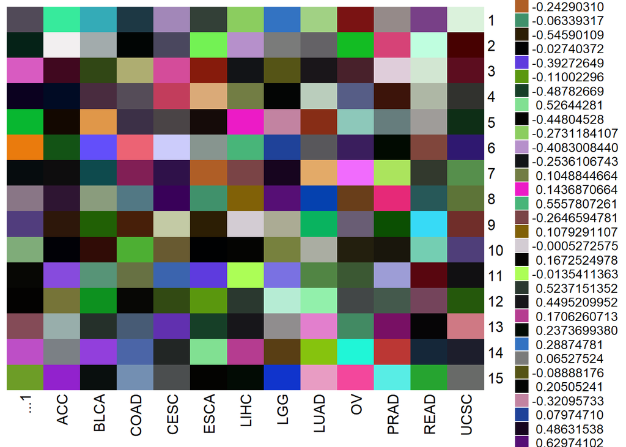

```r
> Heatmap(mat)
```

```r
> col_fun = colorRamp2(c(-2, 0, 2), c("green", "white", "red"))
> col_fun(seq(-3, 3))
```

```
[1] "#00FF00FF" "#00FF00FF" "#B1FF9AFF" "#FFFFFFFF" "#FF9E81FF" "#FF0000FF"
[7] "#FF0000FF"
```

[figure not shown]

```r
> Heatmap(mat, name = "mat", col = col_fun)
```

### 4.9.2 LASSO回归(套索回归)

(glmnet包)  
对于变量过多而且变量数较少的模型拟合, 首先要考虑使用LASSO惩罚函数  
#### 例一

##### 4.9.2.0.1 导入数据/删除缺失值

```r
> bc <- import("D:/desktop/book/book/case/Breast cancer survival agec.sav")
> bc <- na.omit(bc)#返回删除NA后的向量
```

##### 4.9.2.0.2 数据转换成矩阵

glmnet包只能接受矩阵形式的数据

```r
> y <- as.matrix(bc[, 8])#结果
> x <- as.matrix(bc[, c(2:7, 9:11)])#数据的变量
```

##### 4.9.2.0.3 构建模型

```r
> f1 = glmnet(x, y, family = "binomial", nlambda = 100, alpha = 1)
> #print(f1)#把f1结果输出
```

这里alpha = 1为LASSO回归, 如果等于0就是岭回归  
参数 family规定了回归模型的类型：  
family = “gaussian” 适用于一维连续因变量(univariate)  
family = “mgaussian” 适用于多维连续因变量(multivariate)  
family = “poisson” 适用于非负次数因变量(count)  
family = “binomial” 适用于二元离散因变量(binary)  
family = “multinomial” 适用于多元离散因变量(category)  
我们这里结局指标是2分类变量, 所以使用binomial

##### 4.9.2.0.4 输出图形

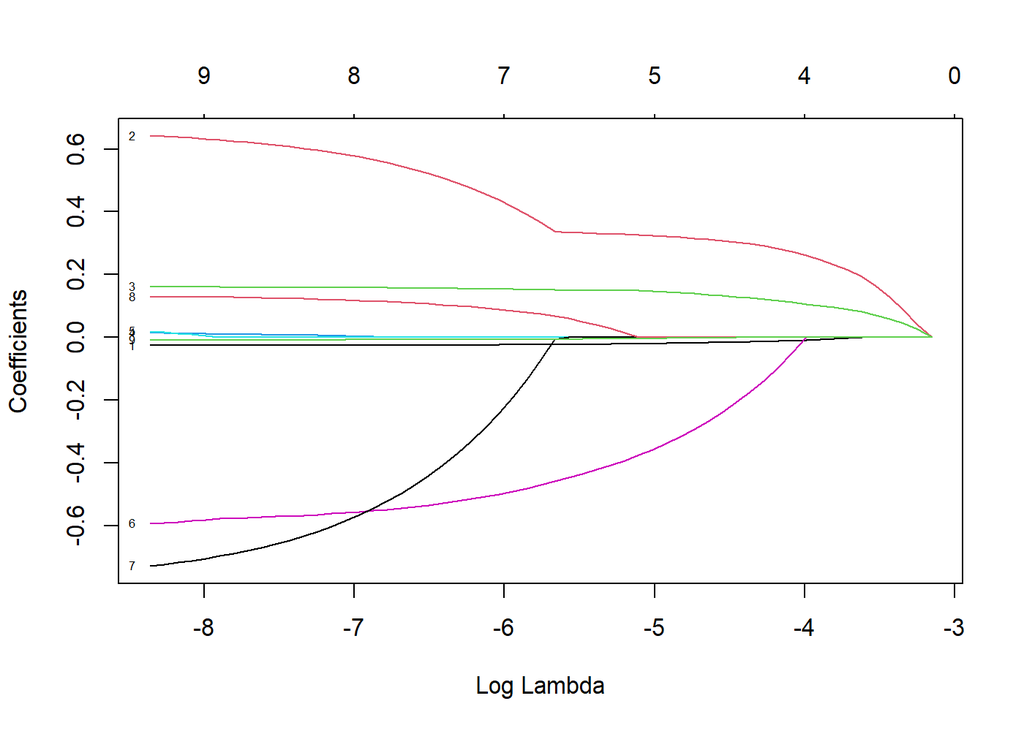

```r
> plot(f1, xvar = "lambda", label = TRUE)
```

##### 4.9.2.0.5 交叉验证

```r
> #predict(f1, newx = x[2:5, ], type = "response")
```

##### 4.9.2.0.6 进行交叉检验, 并输出图形

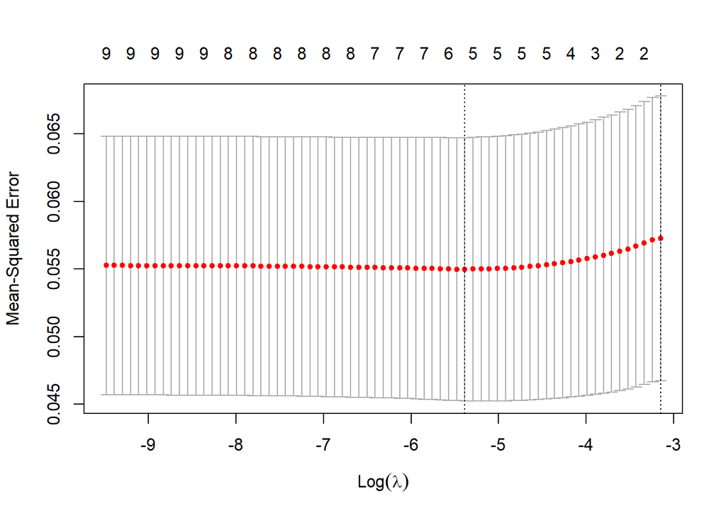

```r
> cvfit = cv.glmnet(x, y)
> plot(cvfit)
```

### 4.9.3 配对图

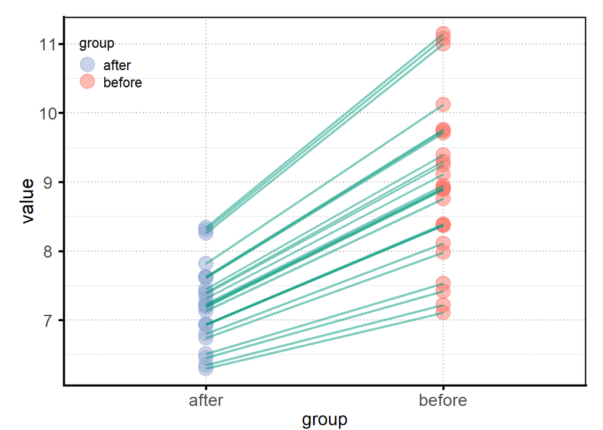

```r
> p箱线图 <- p配对框架+
+  geom_point(size = 5, alpha = 0.5, shape = 21, stroke = 1)+
+  geom_line(aes(group = n), alpha = 0.5, linetype = 1, size = 1, color = "#00997B")+
+  theme(legend.position = (c(0.15, 0.95)))+
+  scale_color_manual(values = cols)+
+  scale_fill_manual(values = fills)
> p箱线图
```

### 4.9.4 细胞毒IC50(OD)

p框架 <- ggplot(x, aes(x = group, y = value))+t_theme p <- p框架+ geom_point(size = 3, shape = 21, stroke = 1, alpha = 0.5) p

```r
> x <- import("D:/desktop/book/book/case/细胞毒实验OD值.xlsx")
> #x整理 <- gather(x, group, value, 0, 1, 2, 4, 8, 16, 32, 64, 128, 256)
> #x整理
```

### 4.9.5 ROC曲线

## 4.10 其他

### 4.10.1 坐标轴截断

(ggbreak包)

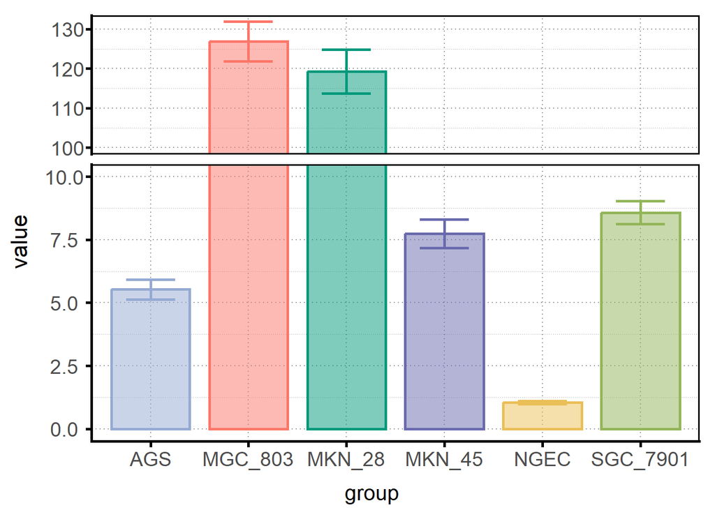

```r
> D <- import("D:/desktop/book/book/case/case_1/3.xlsx")
> D整理 <- gather(D, group, value, NGEC, AGS, MKN_28, MGC_803, MKN_45, SGC_7901)
> p截断 <- ggplot(D整理, aes(x = group, y = value, color = group, fill = group))+
+   stat_summary(fun.data = mean_sdl, fun.args = list(mult = 1), geom = "errorbar", width = 0.5, size = 1, alpha = 1)+
+   stat_summary(fun.data = mean_sdl, fun.args = list(mult = 1), geom = "col", width = 0.8, size = 1, alpha = 0.5)+
+   scale_color_manual(values = cols)+
+   scale_fill_manual(values = fills)+
+   scale_y_break(c(10, 100), ticklabels = NULL, scales = 0.5)+
+   t_theme+
+   theme(legend.position = "none")
> p截断
```

### 4.10.2 双Y坐标轴

ggplot2 不适合双Y坐标轴

### 4.10.3 和弦图

(circlize包) link.sort = F, link.decreasing = F, annotationTrack = “grid”, preAllocateTracks = list(track.height = 0.1) df = data.frame(from = rep(rownames(w), times = ncol(w)), to = rep(colnames(w), each = nrow(w)), value = as.vector(w), stringsAsFactors = FALSE)

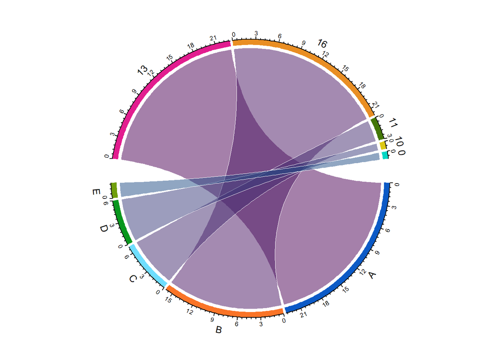

```r
> p和弦图 <- chordDiagram(w,
+  grid.border = NA,
+  transparency = 0.5,#透明度
+  #annotationTrack = NULL,
+  col = hcl.colors(20),
+  link.lwd = 0.05,#宽度
+  link.lty = 1,#线型
+  link.border = 0,#颜色
+ )
```

```r
> p和弦图
```

```
  rn cn value1 value2 o1 o2 x1 x2       col
1  A 13     23     23  1  1 23 23 #4B00557F
2  B 16     16     22  1  1 16 22 #4915627F
3  C 11      7      3  1  1  7  3 #432A6F7F
4  D 10      6      1  1  1  6  1 #383B7A7F
5  E  0      2      1  1  1  2  1 #214C857F
```

```r
> circos.clear()
```

### 4.10.4 词云图

(ggwordcloud包) 2013-2020年中国总理记者会关键词词频  
来源:新华社

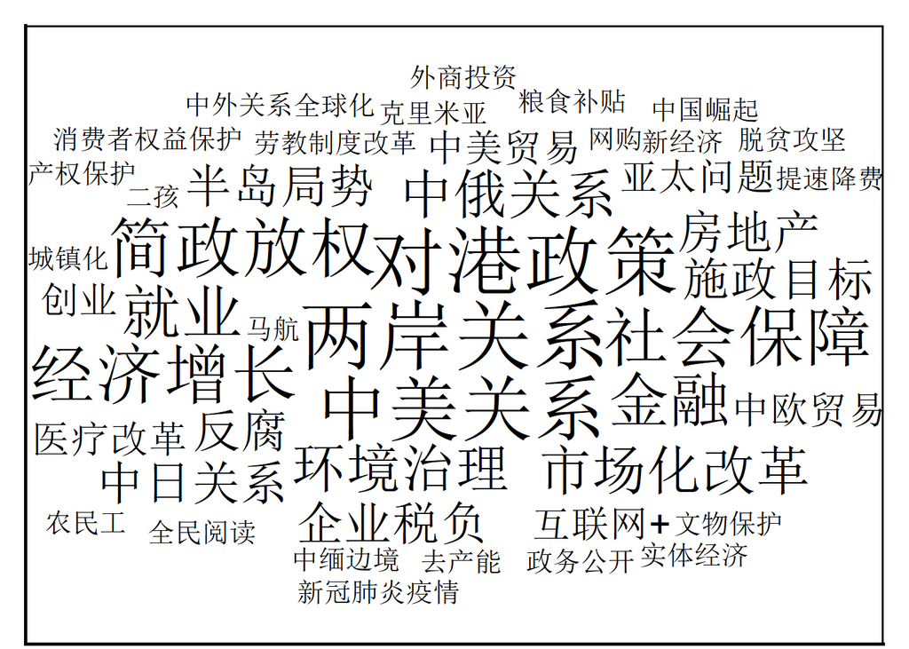

```r
> p词云图 <- ggplot(e, aes(label = words, size = value))+
+  geom_text_wordcloud(family = "Source Han Sans", color = 1)+
+  scale_size_area(max_size = 15)+
+  t_theme
> p词云图
```

### 4.10.5 生存曲线

(survminer包)(survival包)

#### 4.10.5.1 例一

```r
> fit <- survfit(Surv(time, status)~group, data = r1)#创建生存对象, 数据集来源
> fit
```

```
Call: survfit(formula = Surv(time, status) ~ group, data = r1)

             n events median 0.95LCL 0.95UCL
group=High 114     25    806     444      NA
group=Low  114     36    588     529      NA
```

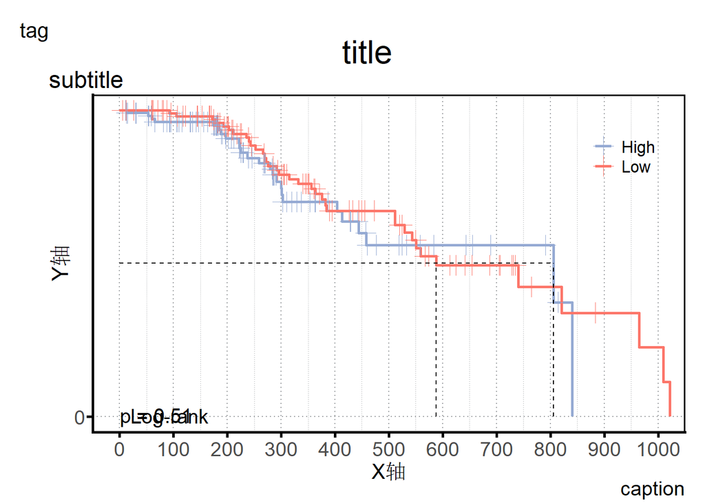

```r
> p <- ggsurvplot(
+   fit,
+   data = r1,
+   fun  = "pct",#"cumhaz"绘制累计风险曲线, "pct"绘制生存概率"event"绘制累计事件
+   palette = c("#95AAD3", "#FC766A"),#自定义调色板'
+   linetype = 1,
+   #conf.int = TRUE,#增加置信区间
+   pval = TRUE,#添加P值
+   pval.method = T,
+   test.for.trend = FALSE,
+   surv.median.line = "hv",#增加中位生存时间
+   risk.table  = F,#添加风险表
+   #cumevents = FALSE,
+   #cumcensor = FALSE,
+   tables.height = 0.3,#主要生存图下所有表格的高度
+   #add.all = TRUE,#添加总患者生存曲线
+   size = 1,
+   xlab = "Follow up time(d)",#指定x轴标签
+   legend = c(0.95, 0.95),#指定图例位置
+   legend.title = "",#设置图例标题
+   legend.labs = c("High", "Low"),#指定图例分组标签
+   surv.plot.height = 0.7,
+   break.x.by = 100,#设置x轴刻度间距
+   break.y.by = 10,#设置x轴刻度间距
+   surv.scale = "default",#"percent"
+   xlim = c(0, 1000),
+   ylim = c(0, 100),
+   axes.offset = T,
+   #conf.int.fill = c("#95AAD3", "#FC766A"),
+   conf.int.style = "ribbon",#"step"ribbon
+   conf.int.alpha = 0.3,
+   pval.size = 5,
+   pval.coord = c(0.5, 0.5),
+   censor = T,
+   censor.size = 4.5,
+   censor.shape = 3,
+   tables.col = "strata",
+   fontsize = 5,
+   font.family = "Source Han Sans",
+   tables.y.text = T,
+   tables.y.text.col = F,
+   risk.table.title = "",
+   risk.table.pos = "out",
+   ggtheme = t_theme,
+   tables.theme = t_theme)+
+   labs(x = "X轴", y = "Y轴", title = "title", subtitle = "subtitle", caption = "caption", tag = "tag")
> p
```

#### 4.10.5.2 例二

```r
> fit <- survfit(Surv(time, status)~sex, data = r2)#创建生存对象, 数据集来源
> fit
```

```
Call: survfit(formula = Surv(time, status) ~ sex, data = r2)

        n events median 0.95LCL 0.95UCL
sex=1 138    112    270     212     310
sex=2  90     53    426     348     550
```

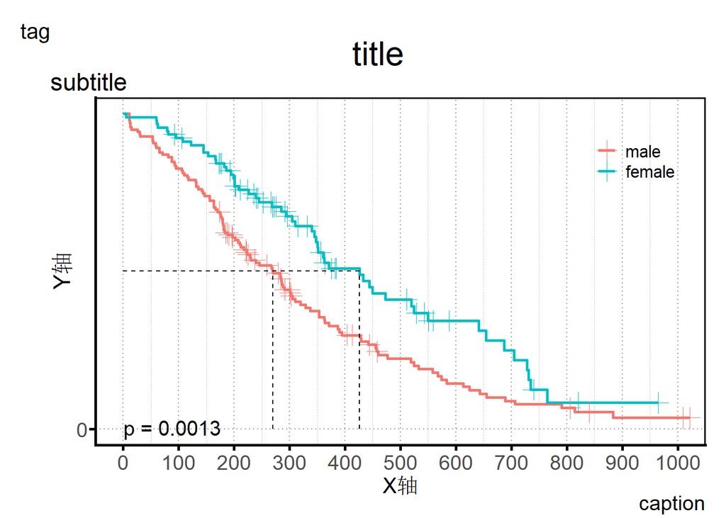

```r
> p <- ggsurvplot(fit,
+  data = r2,
+  size = 1,
+  linetype = 1,
+  surv.median.line = "hv",#增加中位生存时间
+  fun  = "pct",#"cumhaz"绘制累计风险曲线, "pct"绘制生存概率"event"绘制累计事件
+  risk.table  = F,#添加风险表
+  pval = TRUE,#添加P值
+  #add.all = TRUE,#添加总患者生存曲线
+  palette = "hue",#自定义调色板
+  xlab = "Follow up time(d)",#指定x轴标签
+  legend = c(0.95, 0.95),#指定图例位置
+  legend.title = "",#设置图例标题
+  legend.labs = c("male", "female"),#指定图例分组标签
+  surv.plot.height = 0.7,
+  tables.height = 0.3,#主要生存图下所有表格的高度
+  break.x.by = 100,#设置x轴刻度间距
+  break.y.by = 10,#设置x轴刻度间距
+  surv.scale = "default",#"percent"
+  xlim = c(0, 1000),
+  ylim = c(0, 100),
+  axes.offset = T,
+  #conf.int = TRUE,#增加置信区间
+  #conf.int.fill = c("#95AAD3", "#FC766A"),
+  conf.int.style = "ribbon",#"step"ribbon
+  conf.int.alpha = 0.3,
+  pval.size = 5,
+  pval.coord = c(0.5, 0.5),
+  censor = T,
+  censor.size = 4.5,
+  censor.shape = 3,
+  tables.col = "strata",
+  fontsize = 5,
+  font.family = "Source Han Sans",
+  tables.y.text = T,
+  tables.y.text.col = F,
+  risk.table.title = "",
+  risk.table.pos = "out",
+  ggtheme = t_theme)+
+ labs(x = "X轴", y = "Y轴", title = "title", subtitle = "subtitle", caption = "caption", tag = "tag")
> p
```

#### 4.10.5.3 例三

```r
> fit <- survfit(Surv(time, status)~sex, data = r3)#创建生存对象, 数据集来源
> fit
```

```
Call: survfit(formula = Surv(time, status) ~ sex, data = r3)

             n events median 0.95LCL 0.95UCL
sex=Female  90     37    529     376      NA
sex=Male   138     26    840     806      NA
```

[figure not shown]

```r
> p <- ggsurvplot(fit,
+  data = r3,
+  size = 1,
+  linetype = 1,
+  surv.median.line = "hv",#增加中位生存时间
+  fun  = "pct",#"cumhaz"绘制累计风险曲线, "pct"绘制生存概率"event"绘制累计事件
+  risk.table  = F,#添加风险表
+  pval = TRUE,#添加P值
+  #add.all = TRUE,#添加总患者生存曲线
+  palette = "hue",#自定义调色板
+  xlab = "Follow up time(d)",#指定x轴标签
+  legend = c(0.95, 0.95),#指定图例位置
+  legend.title = "",#设置图例标题
+  legend.labs = c("Male", "Female"),#指定图例分组标签
+  surv.plot.height = 0.7,
+  tables.height = 0.3,#主要生存图下所有表格的高度
+  break.x.by = 100,#设置x轴刻度间距
+  break.y.by = 10,#设置x轴刻度间距
+  surv.scale = "default",#"percent"
+  xlim = c(0, 1000),
+  ylim = c(0, 100),
+  axes.offset = T,
+  #conf.int = TRUE,#增加置信区间
+  #conf.int.fill = c("#95AAD3", "#FC766A"),
+  conf.int.style = "ribbon",#"step"ribbon
+  conf.int.alpha = 0.3,
+  pval.size = 5,
+  pval.coord = c(0.5, 0.5),
+  censor = T,
+  censor.size = 4.5,
+  censor.shape = 3,
+  tables.col = "strata",
+  fontsize = 5,
+  font.family = "Source Han Sans",
+  tables.y.text = T,
+  tables.y.text.col = F,
+  risk.table.title = "",
+  risk.table.pos = "out",
+  ggtheme = t_theme)+
+ labs(x = "X轴", y = "Y轴", title = "title", subtitle = "subtitle", caption = "caption", tag = "tag")
> p
```

#### 4.10.5.4 例四

```r
> fit <- survfit(Surv(time, status)~group, data = r4)#创建生存对象, 数据集来源
> fit
```

```
Call: survfit(formula = Surv(time, status) ~ group, data = r4)

          n events median 0.95LCL 0.95UCL
group=a  90     51    426     348     550
group=b 138    112    270     212     310
group=c 131     70    668     500     775
```

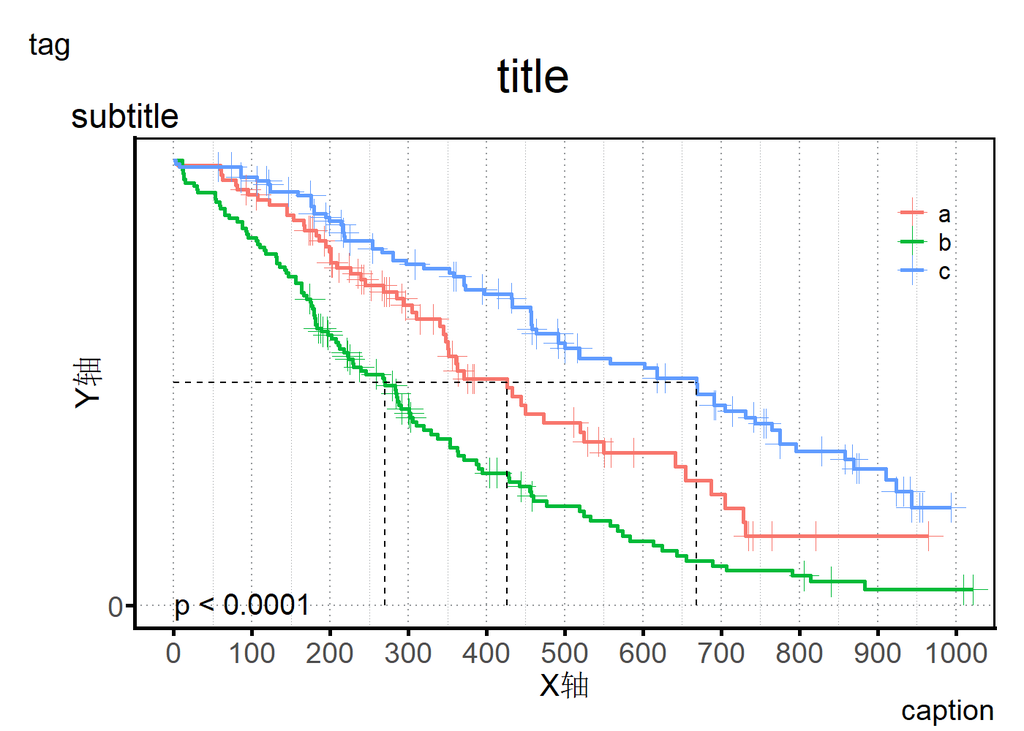

```r
> p <- ggsurvplot(fit,
+  data = r4,
+  size = 1,
+  linetype = 1,
+  surv.median.line = "hv",#增加中位生存时间
+  fun  = "pct",#"cumhaz"绘制累计风险曲线, "pct"绘制生存概率"event"绘制累计事件
+  risk.table  = F,#添加风险表
+  pval = TRUE,#添加P值
+  #add.all = TRUE,#添加总患者生存曲线
+  palette = "hue",#自定义调色板
+  xlab = "Follow up time(d)",#指定x轴标签
+  legend = c(0.95, 0.95),#指定图例位置
+  legend.title = "",#设置图例标题
+  legend.labs = c("a", "b", "c"),#指定图例分组标签
+  surv.plot.height = 0.7,
+  tables.height = 0.3,#主要生存图下所有表格的高度
+  break.x.by = 100,#设置x轴刻度间距
+  break.y.by = 10,#设置x轴刻度间距
+  surv.scale = "default",#"percent"
+  xlim = c(0, 1000),
+  ylim = c(0, 100),
+  axes.offset = T,
+  #conf.int = TRUE,#增加置信区间
+  #conf.int.fill = c("#95AAD3", "#FC766A"),
+  conf.int.style = "ribbon",#"step"ribbon
+  conf.int.alpha = 0.3,
+  pval.size = 5,
+  pval.coord = c(0.5, 0.5),
+  censor = T,
+  censor.size = 4.5,
+  censor.shape = 3,
+  tables.col = "strata",
+  fontsize = 5,
+  font.family = "Source Han Sans",
+  tables.y.text = T,
+  tables.y.text.col = F,
+  risk.table.title = "",
+  risk.table.pos = "out",
+  ggtheme = t_theme)+
+ labs(x = "X轴", y = "Y轴", title = "title", subtitle = "subtitle", caption = "caption", tag = "tag")
> p
```

### 4.10.6 雷达图

(ggradar包)

p雷达图 <- ggradar(t) p雷达图

## 4.11 参考线

### 4.11.1 垂直线

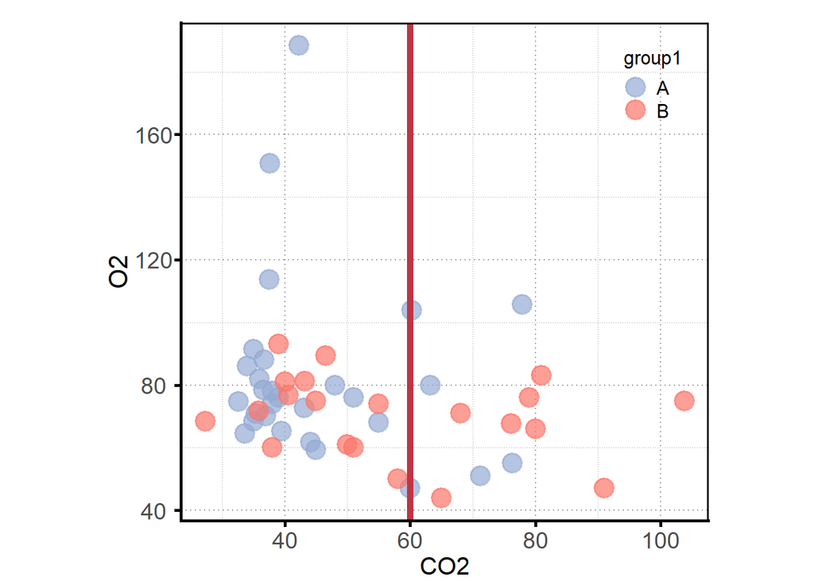

```r
> p垂直线 <- p散点图+
+  geom_vline(xintercept  = 60, linetype  = 1, color  = "#BD3645", size = 2)
> p垂直线
```

### 4.11.2 水平线

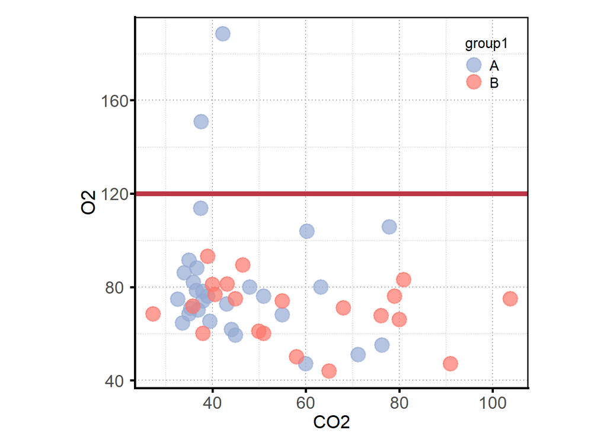

```r
> p水平线 <- p散点图+
+  geom_hline(yintercept  = 120, linetype  = 1, color  = "#BD3645", size = 2)
> p水平线
```

### 4.11.3 函数直线

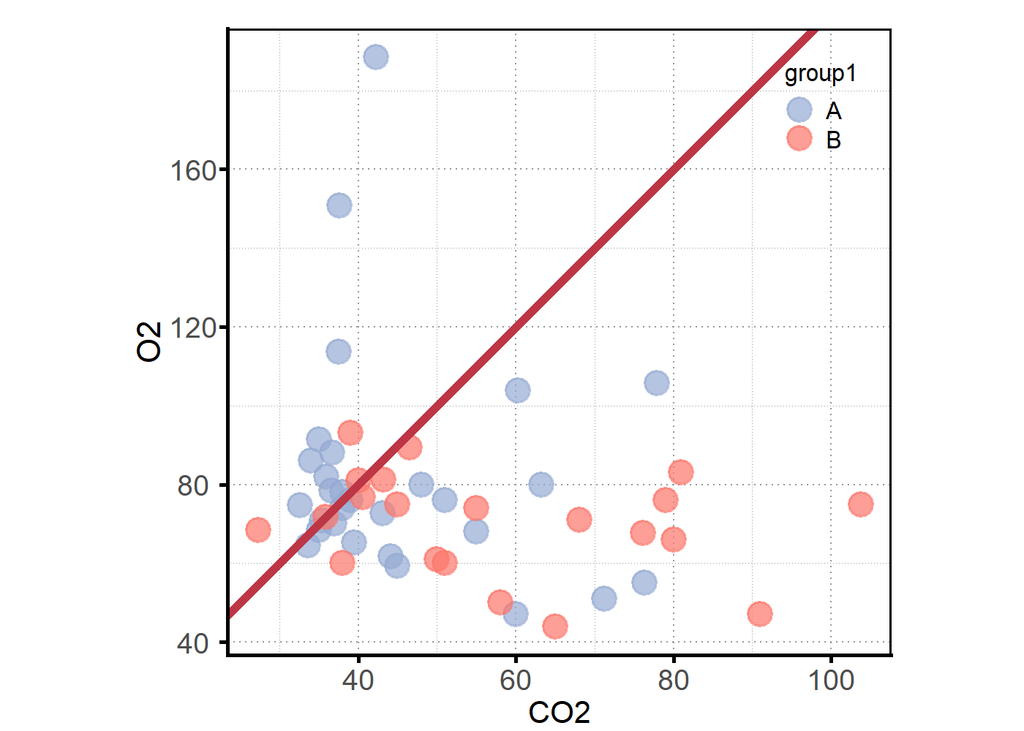

```r
> p对角线 <- p散点图+
+  geom_abline(size = 2, intercept  = 0, slope = 2, color  = "#BD3645")
> p对角线
```

### 4.11.4 线段

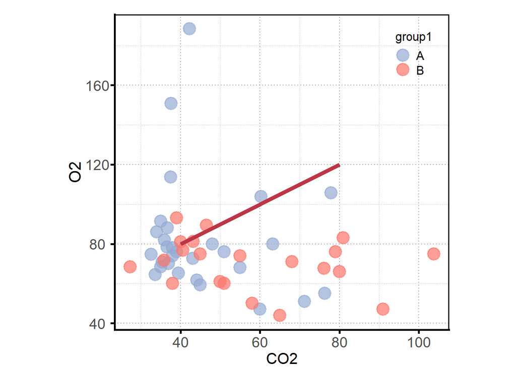

```r
> p线段1 <- p散点图+
+  geom_segment(size = 2, x = 40, y = 80, xend = 80, yend = 120, color = "#BD3645")
> p线段1
```

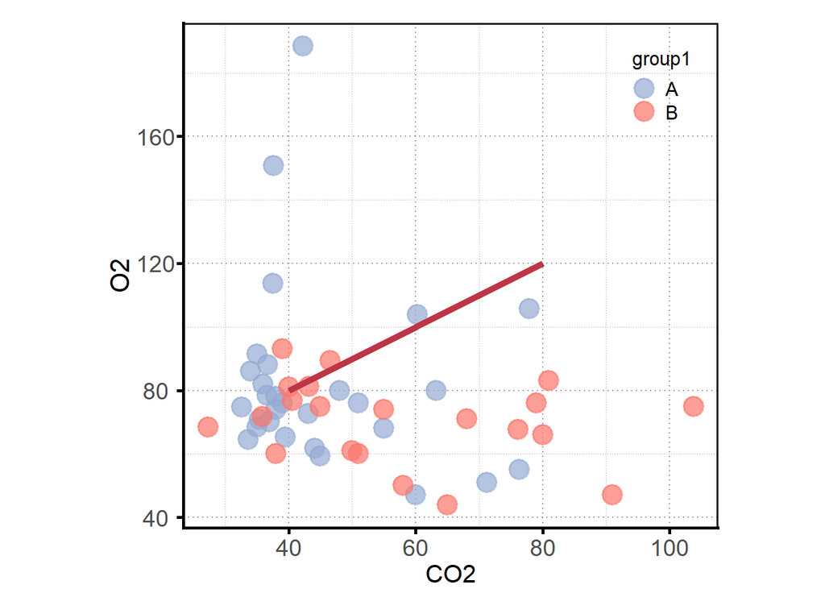

```r
> p线段2 <- p散点图+
+  geom_curve(size = 2, x = 40, y = 80, xend = 80, yend = 120, color = "#BD3645", curvature = 0)
> p线段2
```

### 4.11.5 曲线段

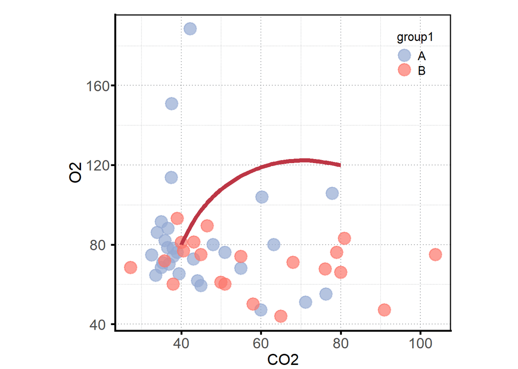

```r
> p左曲线段 <- p散点图+
+  geom_curve(size = 2, x = 40, y = 80, xend = 80, yend = 120, color  = "#BD3645", curvature = -0.4)
> p左曲线段
```

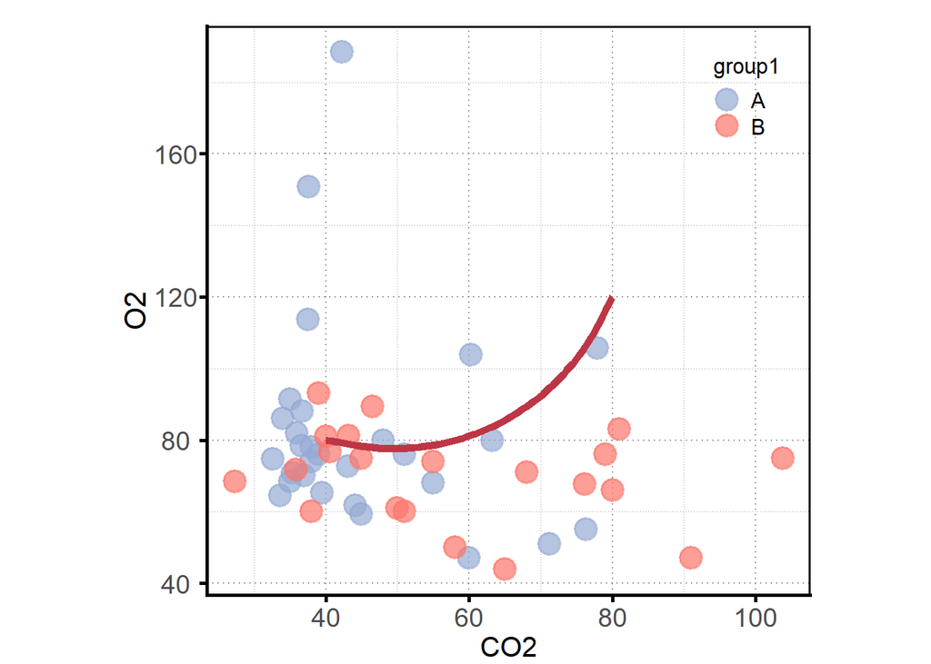

[output not shown]

```r
> p右曲线段 <- p散点图+
+  geom_curve(size = 2, x = 40, y = 80, xend = 80, yend = 120, color  = "#BD3645", curvature = 0.4)
> p右曲线段
```

## 4.12 图片排版(customLayout包)

### 4.12.1 创建画布

```r
> lay1 <- lay_new(
+  matrix(1:4, nc = 2),
+  widths = c(1, 1),
+  heights = c(1, 1))
```

```r
> lay2 <- lay_new(
+  matrix(1:4, nc = 2),
+  widths = c(1, 1),
+  heights = c(1, 1))
```

### 4.12.2 画布列拼接

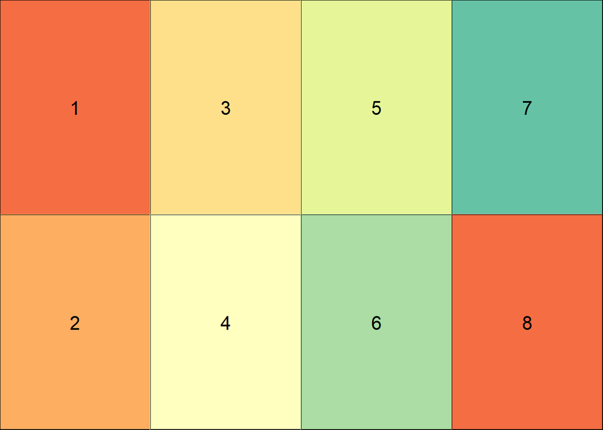

```r
> col <- lay_bind_col(lay1, lay2, widths = c(1, 1))
> lay_show(col)
```

### 4.12.3 画布行拼接

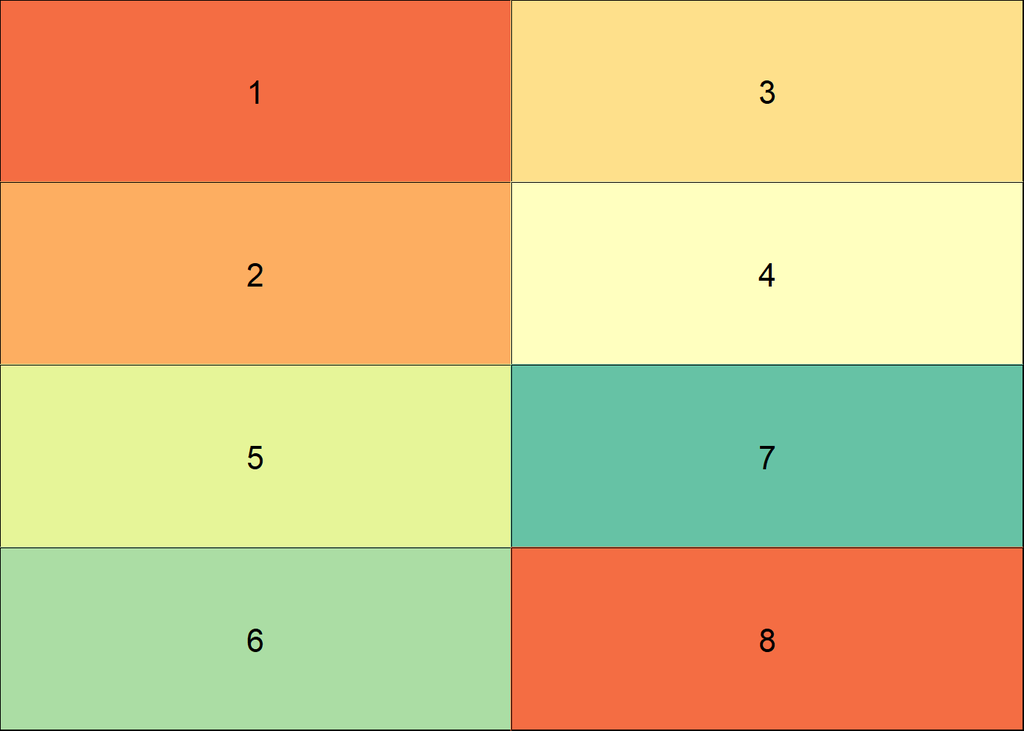

```r
> row <- lay_bind_row(lay1, lay2, heights = c(1, 1))
> lay_show(row)
```

### 4.12.4 内拼接画布

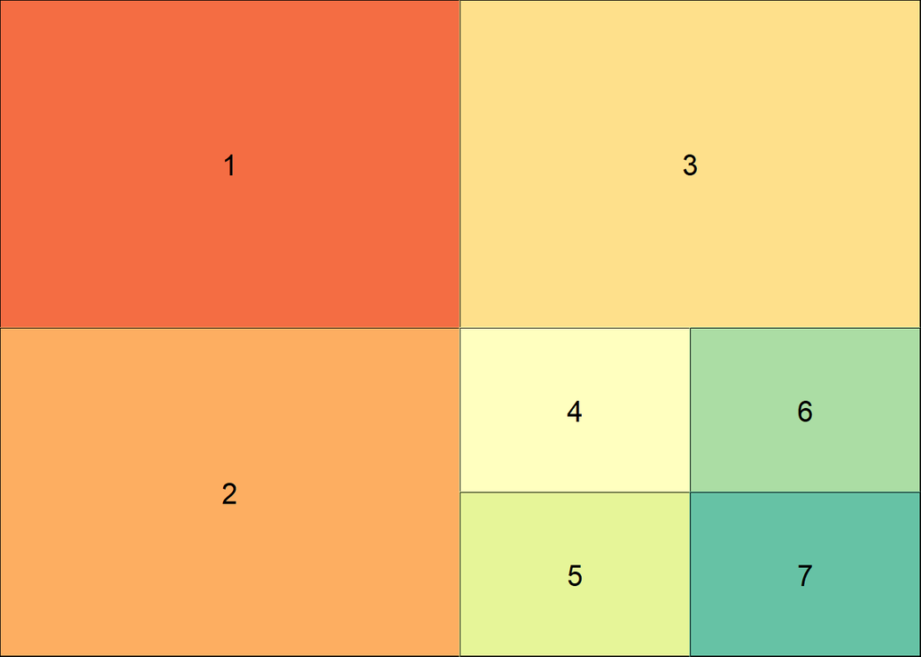

```r
> inside <- lay_split_field(lay1, lay2, field = 4)
> lay_show(inside)
```

### 4.12.5 拼接

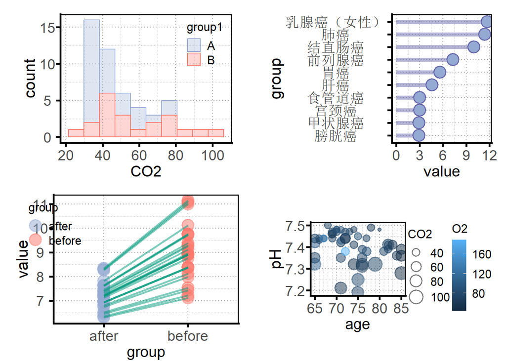

```r
> m <- lay_grid(list(p直方图, p箱线图, p棒棒糖图, p气泡图), lay1)
```

# 5 案例

## 5.1 案例1

### 5.1.1 散点图A

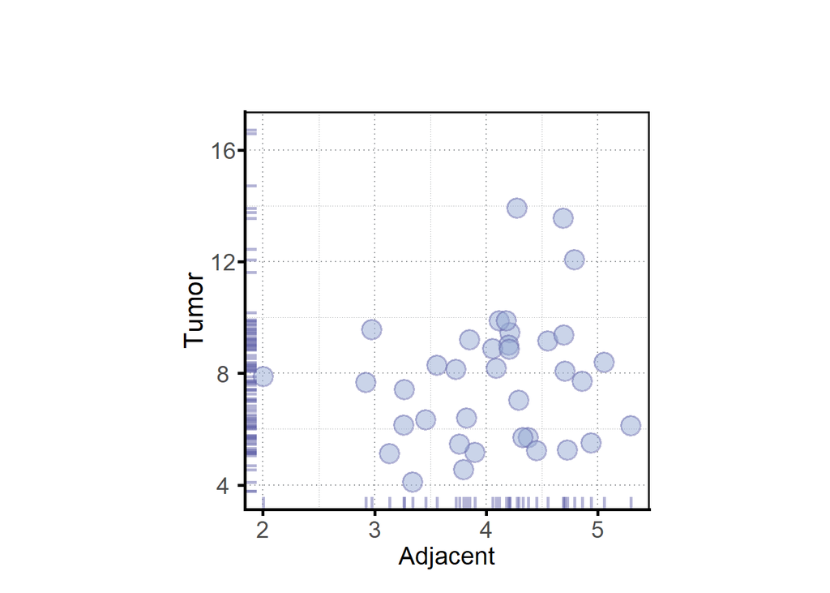

```r
> A <- import("D:/desktop/book/book/case/case_1/0.xlsx")
> p散点图a <- ggplot(A, aes(Adjacent, Tumor))+
+  geom_point(shape = 21, alpha = 0.5, color = "#696AAD", fill = "#95AAD3", stroke = 1, size = 5)+
+  geom_rug(linetype = 1, alpha = 0.5, color = "#696AAD", size = 1)+
+  coord_fixed(ratio = 1/4)+
+  t_theme+
+  labs(x = "Adjacent", y = "Tumor", title = "", subtitle = "", caption = "", tag = "")
> p散点图a
```

### 5.1.2 折线图B

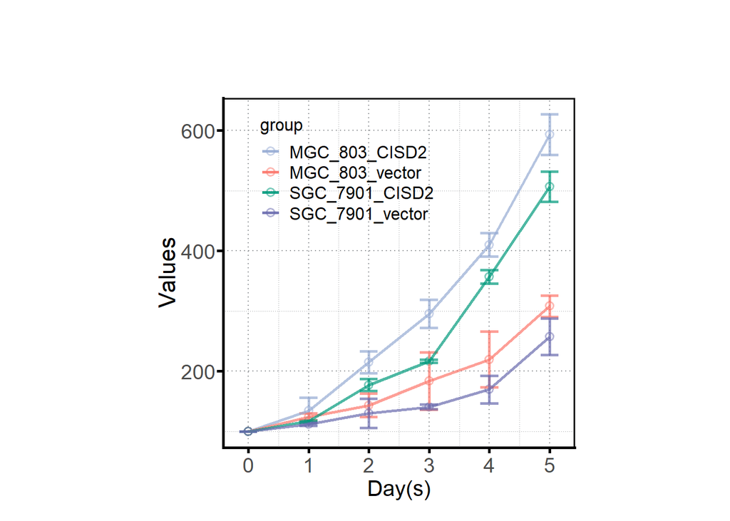

```r
> B <- import("D:/desktop/book/book/case/case_1/1.xlsx")
> B整理 <- gather(B, group, value, MGC_803_vector, MGC_803_CISD2, SGC_7901_vector, SGC_7901_CISD2)
> p折线图b <- ggplot(B整理, aes(Day, value, color = group, fill = group))+
+  stat_summary(fun.data = mean_sdl, fun.args = list(mult = 1), geom = "point", size = 2, shape = 21, alpha = 0.5, stroke = 1, size = 4, fill = NA)+
+  stat_summary(fun.data = mean_sdl, fun.args = list(mult = 1), geom = "errorbar", width = 0.3, alpha = 0.7, size = 1)+
+  stat_summary(fun.data = mean_sdl, fun.args = list(mult = 1), geom = "line", alpha = 0.7, size = 1)+
+  scale_color_manual(values = cols)+
+  scale_fill_manual(values = fills)+
+  coord_fixed(ratio = 2/200)+
+  t_theme+
+  theme(legend.position = (c(0.6, 0.95)))+
+  labs(x = "Day(s)", y = "Values", title = "", subtitle = "", caption = "", tag = "")
> p折线图b
```

### 5.1.3 柱状图1C

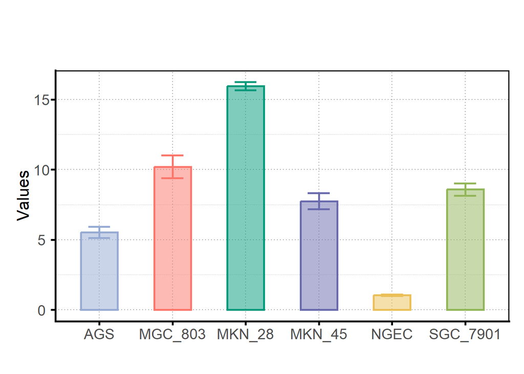

```r
> C <- import("D:/desktop/book/book/case/case_1/2.xlsx")
> C整理 <- gather(C, group, value, NGEC, AGS, MKN_28, MGC_803, MKN_45, SGC_7901)
> p柱状图c <- ggplot(C整理, aes(x = group, y = value, color = group, fill = group))+
+  stat_summary(fun.data = mean_sdl, fun.args = list(mult = 1), geom = "errorbar", width = 0.3, alpha = 1, size = 1)+
+  stat_summary(fun.data = mean_sdl, fun.args = list(mult = 1), geom = "col", width = 0.5, alpha = 0.5, size = 1)+
+  scale_color_manual(values = cols)+
+  scale_fill_manual(values = fills)+
+  t_theme+
+  theme(legend.position = "none")+
+  labs(x = "", y = "Values", title = "", subtitle = "", caption = "", tag = "")
> p柱状图c
```

### 5.1.4 柱状图2D

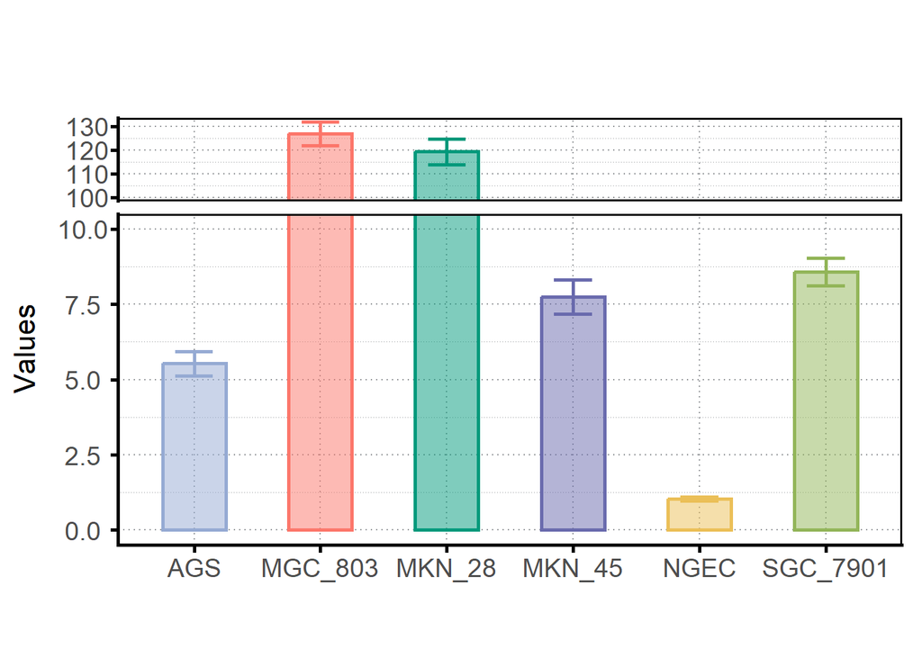

```r
> D <- import("D:/desktop/book/book/case/case_1/3.xlsx")
> D整理 <- gather(D, group, value, NGEC, AGS, MKN_28, MGC_803, MKN_45, SGC_7901)
> p柱状图d <- ggplot(D整理, aes(x = group, y = value, color = group, fill = group))+
+  stat_summary(fun.data = mean_sdl, fun.args = list(mult = 1), geom = "errorbar", width = 0.3, alpha = 1, size = 1)+
+  stat_summary(fun.data = mean_sdl, fun.args = list(mult = 1), geom = "col", width = 0.5, alpha = 0.5, size = 1)+
+  scale_color_manual(values = cols)+
+  scale_fill_manual(values = fills)+
+  scale_y_break(c(10, 100), ticklabels = NULL, scales = 0.25)+
+  t_theme+
+  theme(legend.position = "none")+
+  labs(x = "", y = "Values", title = "", subtitle = "", caption = "", tag = "")
> p柱状图d
```

### 5.1.5 对比柱状图E

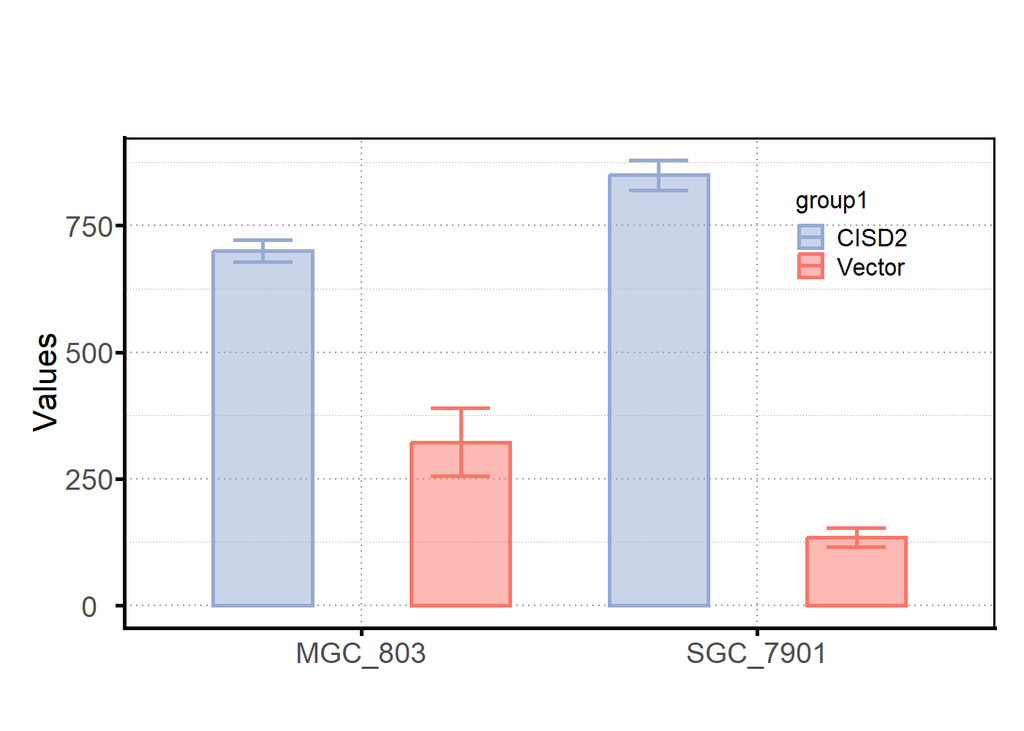

```r
> E <- import("D:/desktop/book/book/case/case_1/4.xlsx")
> E整理 <- gather(E, group2, value, MGC_803, SGC_7901)
> p对比柱状图e <- ggplot(E整理, aes(group2, value, color = group1, fill = group1))+
+  stat_summary(fun.data = mean_sdl, fun.args = list(mult = 1), geom = "errorbar", width = 0.3, alpha = 1, position = position_dodge(width = 1), size = 1)+
+  stat_summary(fun.data = mean_sdl, fun.args = list(mult = 1), geom = "col", width = 0.5, alpha = 0.5, position = position_dodge(width = 1), size = 1)+
+  scale_color_manual(values = cols)+
+  scale_fill_manual(values = fills)+
+  t_theme+
+  theme(legend.position = (c(0.9, 0.9)))+
+  labs(x = "", y = "Values", title = "", subtitle = "", caption = "", tag = "")
> p对比柱状图e
```

### 5.1.6 生存曲线F

```r
> F <- import("D:/desktop/book/book/case/case_1/5.xlsx")
> fit <- survfit(Surv(Time_Months, Status)~Expression, data = F)#创建生存对象, 数据集来源
> fit#查看拟合曲线信息
```

```
Call: survfit(formula = Surv(Time_Months, Status) ~ Expression, data = F)

                 n events median 0.95LCL 0.95UCL
Expression=High 80     47     34      28      39
Expression=Low  80     30     41      33      NA
```

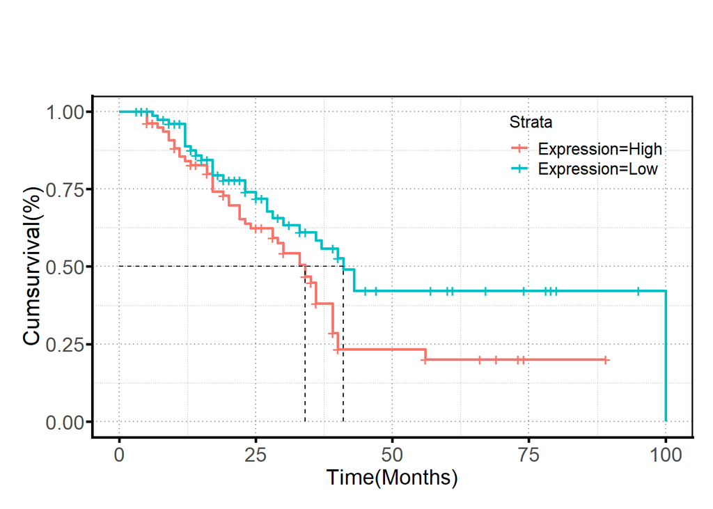

```r
> p生存曲线f <- ggsurvplot(fit,
+  data = F,
+  fun = NULL,
+  linetype = 1,
+  conf.int = FALSE,
+  pval = FALSE,
+  pval.method = FALSE,
+  test.for.trend = FALSE,
+  surv.median.line = "hv",
+  risk.table = FALSE,
+  cumevents = FALSE,
+  cumcensor = FALSE,
+  tables.height = 0.25,
+  legend = c(0.95, 0.95),#指定图例位置
+  facet.by = NULL,
+  font.family = "Source Han Sans",
+  ggtheme = t_theme,
+  add.all = FALSE,
+  combine = FALSE)+
+  labs(x = "Time(Months)", y = "Cumsurvival(%)", title = "", subtitle = "", caption = "", tag = "")
> p生存曲线f
```

### 5.1.7 热图G

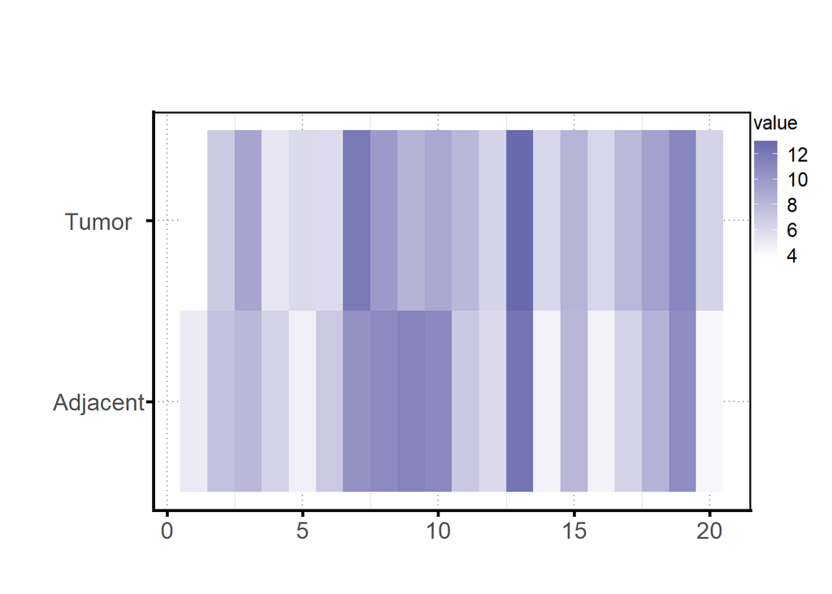

```r
> G <- import("D:/desktop/book/book/case/case_1/6.xlsx")
> G整理 <- gather(G, Group, value, Adjacent, Tumor)
> p热图g <- ggplot(data = G整理, aes(x = ID, y = Group))+
+  geom_tile(alpha = 1, aes(fill = value))+
+  scale_fill_gradient(low = "white", high = "#696AAD")+
+  labs(x = "", y = "", title = "", subtitle = "", caption = "", tag = "")+
+  t_theme
> p热图g
```

## 5.2 案例2

### 5.2.1 散点图

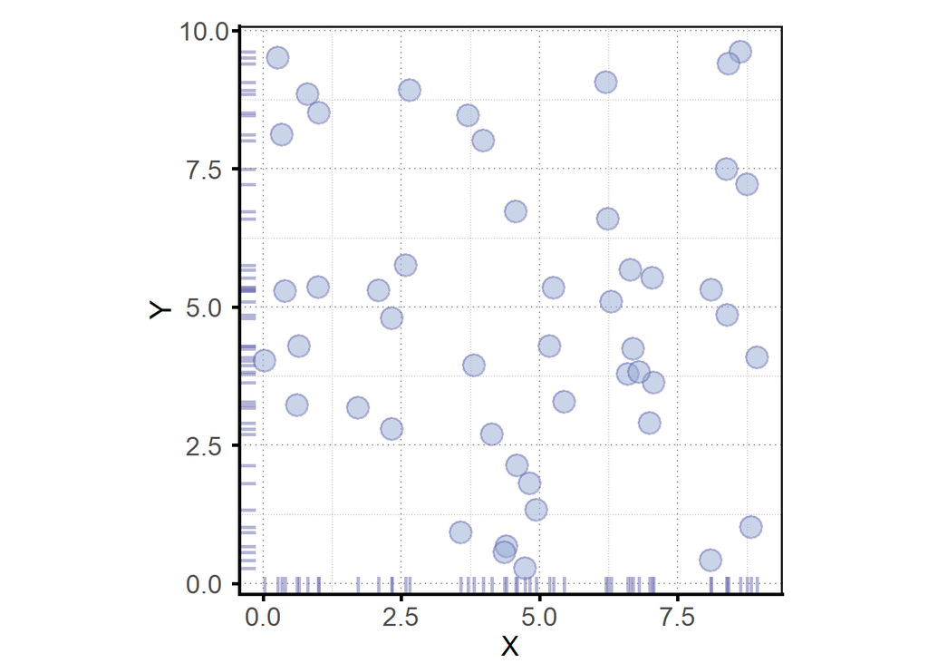

```r
> A <- import("D:/desktop/book/book/case/case_2/0.xlsx")
> p散点图a <- ggplot(A, aes(X, Y))+
+  geom_point(size = 5, shape = 21, alpha = 0.5, color = "#696AAD", fill = "#95AAD3", stroke = 1)+
+  geom_rug(size = 1, linetype = 1, alpha = 0.5, color = "#696AAD")+
+  coord_fixed(ratio = 1/1)+
+  t_theme
> p散点图a
```

### 5.2.2 折线图

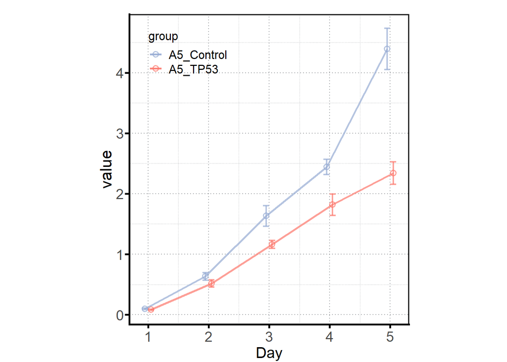

```r
> B <- import("D:/desktop/book/book/case/case_2/1.xlsx")
> B整理 <- gather(B, group, value, A5_Control, A5_TP53)
> p折线图b <- ggplot(B整理, aes(Day, value, color = group, fill = group))+
+  stat_summary(fun.data = mean_sdl, fun.args = list(mult = 1), geom = "point", size = 2, shape = 21, alpha = 0.7, stroke = 1, position = position_dodge(0.2), fill = NA)+
+  stat_summary(fun.data = mean_sdl, fun.args = list(mult = 1), geom = "errorbar", width = 0.2, size = 0.8, alpha = 0.7, position = position_dodge(0.2))+
+  stat_summary(fun.data = mean_sdl, fun.args = list(mult = 1), geom = "line", size = 1, alpha = 0.7, position = position_dodge(0.2))+
+  scale_color_manual(values = cols)+
+  scale_fill_manual(values = fills)+
+  coord_fixed(ratio = 1/1)+
+  t_theme+
+  theme(legend.position = (c(0.35, 0.95)))
> p折线图b
```

### 5.2.3 柱状图1

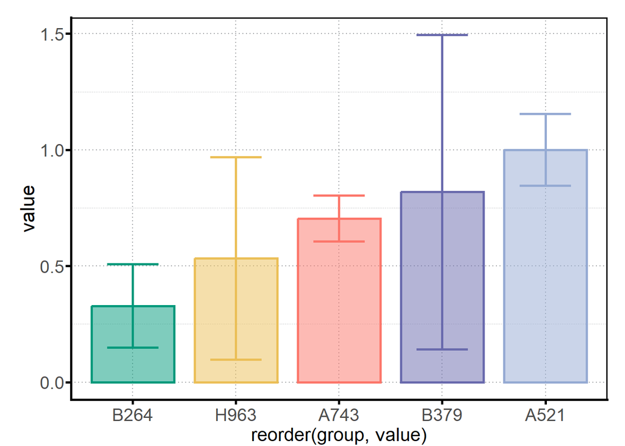

```r
> C <- import("D:/desktop/book/book/case/case_2/2.xlsx")
> C整理 <- gather(C, group, value, A521, A743, B264, B379, H963)
> p柱状图c <- ggplot(C整理, aes(x = reorder(group, value), y = value, color = group, fill = group))+
+  stat_summary(fun.data = mean_sdl, fun.args = list(mult = 1), geom = "errorbar", width = 0.5, size = 1, alpha = 1)+
+  stat_summary(fun.data = mean_sdl, fun.args = list(mult = 1), geom = "col", width = 0.8, size = 1, alpha = 0.5)+
+  t_theme+
+  scale_color_manual(values = cols)+
+  scale_fill_manual(values = fills)+
+  theme(legend.position = ("none"))
> p柱状图c
```

### 5.2.4 对比柱状图1

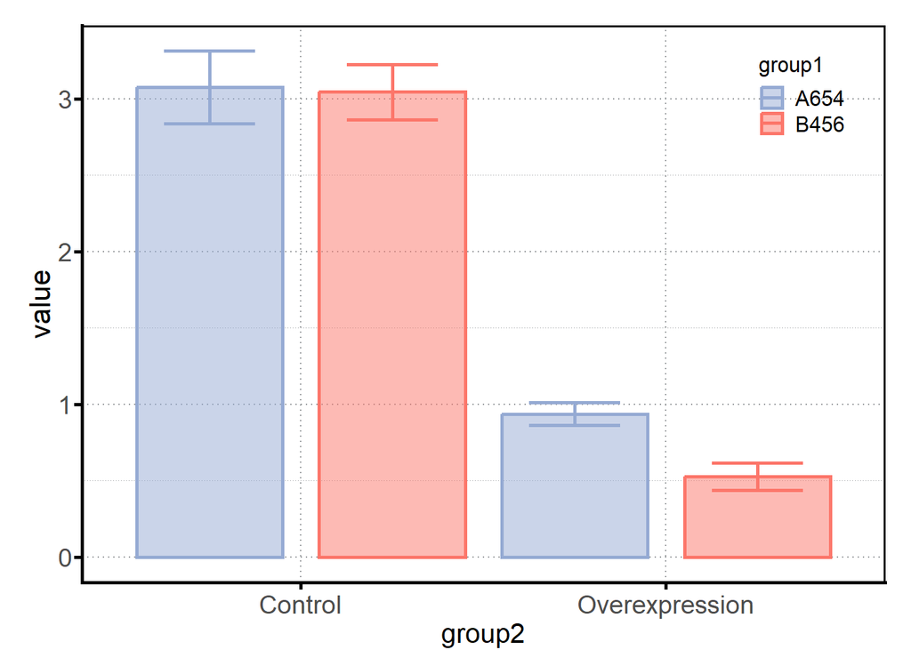

```r
> D <- import("D:/desktop/book/book/case/case_2/3.xlsx")
> D整理 <- gather(D, group2, value, Control, Overexpression)
> p对比柱状图d <- ggplot(D整理, aes(group2, value, color = group1, fill = group1))+
+  stat_summary(fun.data = mean_sdl, fun.args = list(mult = 1), geom = "errorbar", width = 0.5, size = 1, alpha = 1, position = position_dodge(width = 1))+
+  stat_summary(fun.data = mean_sdl, fun.args = list(mult = 1), geom = "col", width = 0.8, size = 1, alpha = 0.5, position = position_dodge(width = 1))+
+  scale_color_manual(values = cols)+
+  scale_fill_manual(values = fills)+
+  t_theme+
+  theme(legend.position = (c(0.95, 0.95)))
> p对比柱状图d
```

### 5.2.5 箱线图

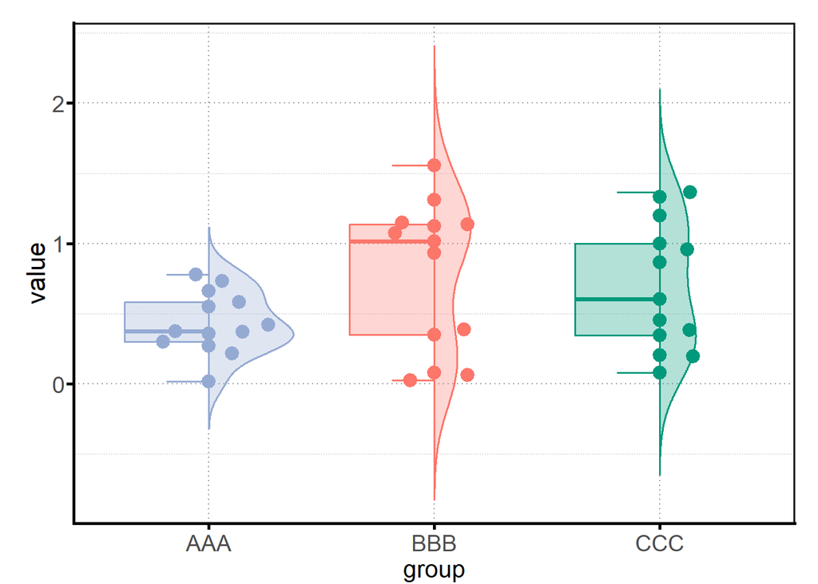

```r
> E <- import("D:/desktop/book/book/case/case_2/4.xlsx")
> E整理 <- gather(E, group, value, AAA, BBB, CCC)
> p箱线图e <- ggplot(E整理, aes(group, value, color = group, fill = group))+
+  geom_half_boxplot(alpha = 0.3, size = 0.618, position = position_nudge(x = 0, y = 0), side = "l", )+
+  geom_half_violin(alpha = 0.3, size = 0.618, position = position_nudge(x = 0, y = 0), side = "r", trim = FALSE)+
+  geom_beeswarm(cex = 5, priority = "density", size = 3, shape = 21, stroke = 1)+#"descending"random""none"点图
+  scale_color_manual(values = cols)+
+  scale_fill_manual(values = fills)+
+  t_theme+
+  theme(legend.position = ("none"))
> p箱线图e
```

### 5.2.6 生存曲线

```r
> F <- import("D:/desktop/book/book/case/case_2/5.xlsx")
> fit <- survfit(Surv(Time_Months, Status)~Expression, data = F)
> fit
```

```
Call: survfit(formula = Surv(Time_Months, Status) ~ Expression, data = F)

                 n events median 0.95LCL 0.95UCL
Expression=High 31     11     NA      43      NA
Expression=Low  37     18     34      23      NA
```

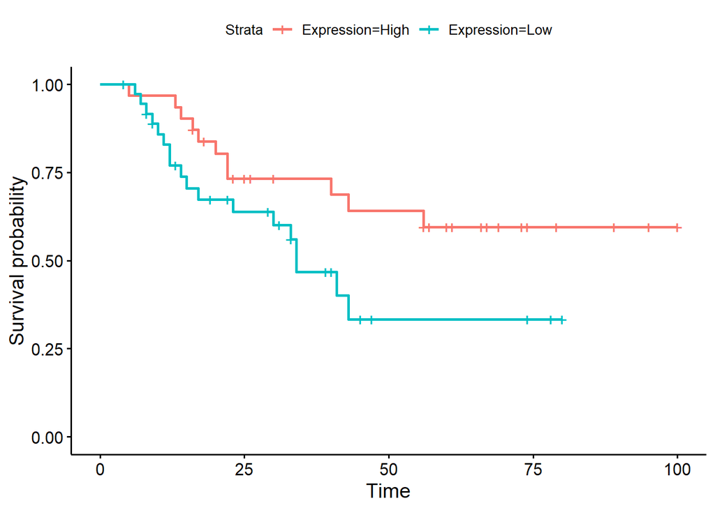

```r
> p生存曲线f <- ggsurvplot(fit, data = F, fun = NULL, linetype = 1, conf.int = FALSE, pval = FALSE, pval.method = FALSE, test.for.trend = FALSE, surv.median.line = "none", risk.table = FALSE, cumevents = FALSE, cumcensor = FALSE, tables.height = 0.25, facet.by = NULL, add.all = FALSE, combine = FALSE)
> p生存曲线f
```

### 5.2.7 柱状图2

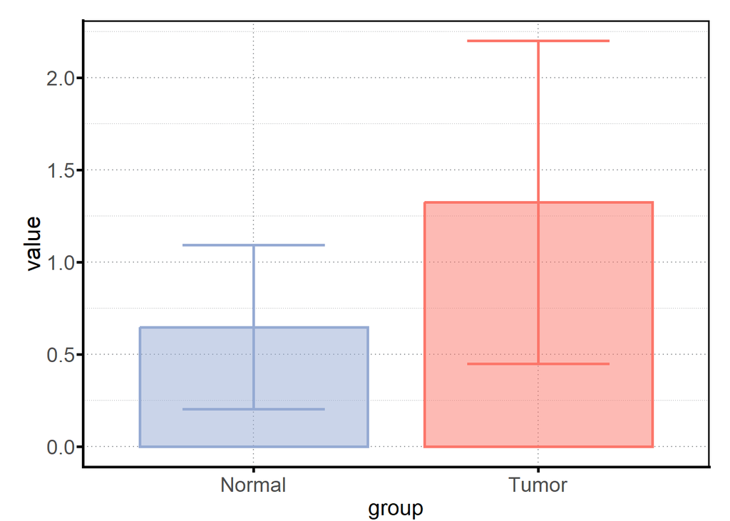

```r
> G <- import("D:/desktop/book/book/case/case_2/6.xlsx")
> G整理 <- gather(G, group, value, Normal, Tumor)
> p柱状图g <- ggplot(G整理, aes(group, value, color = group, fill = group))+
+  stat_summary(fun.data = mean_sdl, fun.args = list(mult = 1), geom = "errorbar", width = 0.5, size = 1, alpha = 1, )+
+  stat_summary(fun.data = mean_sdl, fun.args = list(mult = 1), geom = "col", width = 0.8, size = 1, alpha = 0.5, )+
+  scale_color_manual(values = cols)+
+  scale_fill_manual(values = fills)+
+  t_theme+
+  theme(legend.position = ("none"))
> p柱状图g
```

### 5.2.8 热图

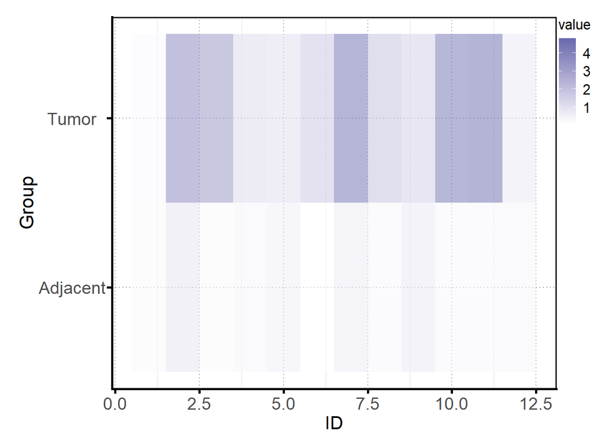

```r
> H <- import("D:/desktop/book/book/case/case_2/7.xlsx")
> H整理 <- gather(H, Group, value, Adjacent, Tumor)
> p热图h <- ggplot(data = H整理, aes(x = ID, y = Group))+
+  geom_tile(alpha = 0.5, aes(fill = value))+
+  scale_fill_gradient(low = "white", high = "#696AAD")+
+  t_theme
> p热图h
```

```r
> library(hexSticker)
```

```r
> sticker(p热图h,package="YuriR", p_size=123.6, s_x=1, s_y=0.618,s_width=1.3,s_height=1,filename="D:/desktop/book/book/ggplot2.png",dpi=1200,h_fill="#34558B",h_color="#FC766A",h_size=1,p_family="A",p_x=1,p_y=1.236)
```

# 6 参考文献

```r
> #p_cite(rio)
> #p_cite(data.table)
> #p_cite(tidyverse)
> #p_cite(ggbeeswarm)
> #p_cite(gghalves)
> #p_cite(MASS)
> #p_cite(hexbin)
> #p_cite(ggExtra)
```